# cm005

## Exercise 3: Fix the plots (Together)

### 3(a)

Fix the following plot (attribution: [“R for data science”](https://r4ds.had.co.nz/data-visualisation.html)).

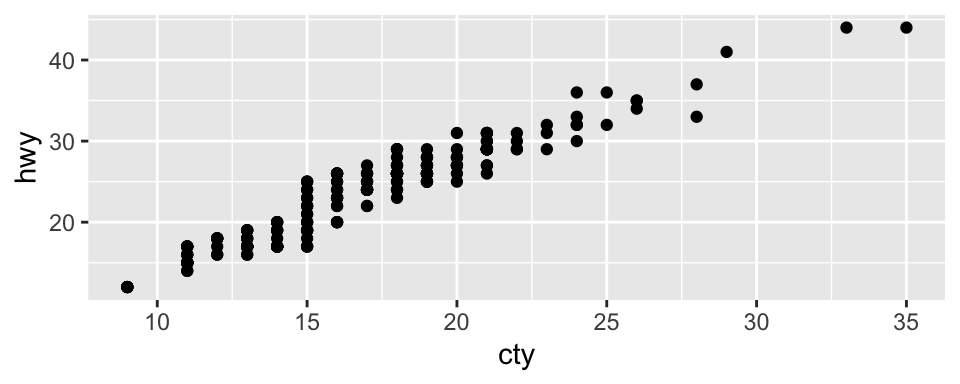

```r
ggplot(mpg, aes(cty, hwy)) +
  geom_point()
```

### 3(b)

Fix this plot so that it shows life expectancy over time *for each country*.

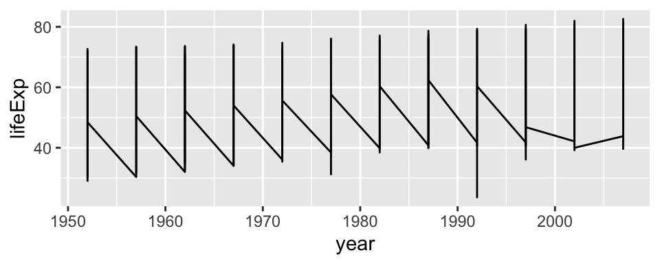

```r
ggplot(gapminder, aes(year, lifeExp)) +
    geom_line()
```

### 3(c)

The following mock data set marks the (x,y) position of a caribou at four time points. Fix the plot below so that it shows the path of the caribou. Add an arrow with `arrow = arrow()`.

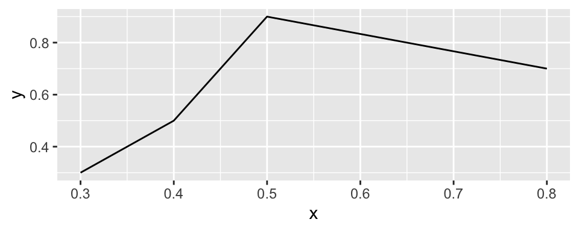

```r
motion <- tribble(
  ~time, ~x, ~y,
  1, 0.3, 0.3,
  2, 0.8, 0.7,
  3, 0.5, 0.9,
  4, 0.4, 0.5
)
ggplot(motion, aes(x, y)) +
  geom_line()
```

### 3(d)

The following plot attempts to put both the raw data and boxplots together, but it’s hard to see the raw data. Fix the plot.

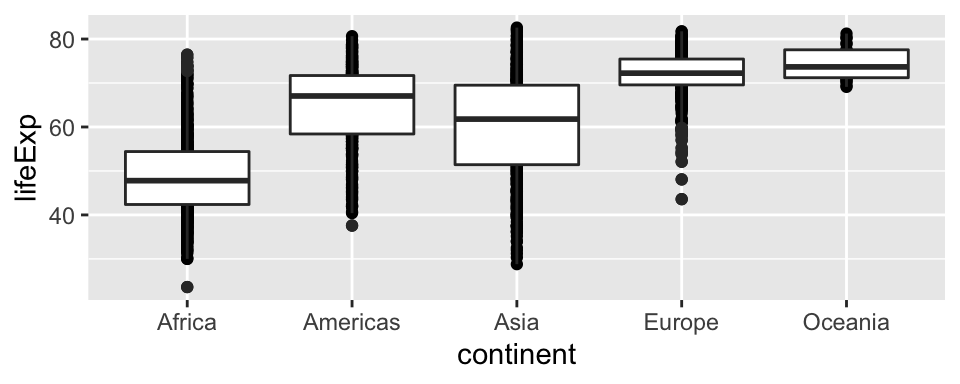

```r
ggplot(gapminder, aes(continent, lifeExp)) +
  geom_point() +
  geom_boxplot()
```

### 3(e)

Change the following plot so that it shows *proportion* on the y-axis, not count.

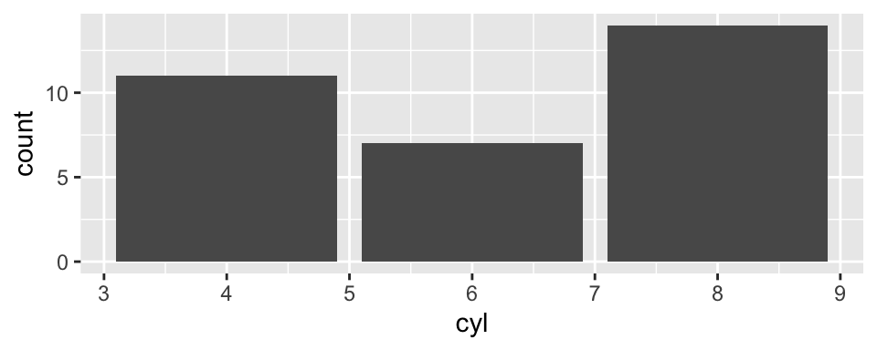

```r
ggplot(mtcars, aes(cyl)) +
  geom_bar()
```